# EEG studies

```python
"""
Necessary Packages
"""
import os
import matplotlib.pyplot as plt
import numpy as np
import pandas as pd
import scipy.stats
#ADVANCED
import seaborn as sns
import warnings
from pylab import rcParams


#e2_functions
import e2_functions_v8 as e2_f
```

```python
#SET PLOT PARAMETERS For Jupyter (ADVANCED)
%matplotlib inline
warnings.filterwarnings("ignore")
rcParams['figure.figsize'] = 80,60
rcParams['font.size'] = 15
sns.set()
```

```python
#DATA DIR
datadir=os.getcwd()
database="e2_database_v4.xlsx" #STUDY_2; #NOTE: DON'T REMOVE EMPTY COLUMNS
database_path=os.path.join(datadir, database)
```

```python
#eeg responders & non-responders
eeg_alpha_groups = pd.read_excel(database_path, sheet_name='alpha_groups')
#eeg_alpha_groups
```

# Within Subjects

```
INFO:e2_functions_v8:
>> PROCESSING PLOT SUBJECT:  S061, epoch_a
```

```
rest_eo_2
alpha_eo_3
imageryv6_eo_4
alpha_eo_5
breathingv6_eo_10
alpha_eo_11
alpha_eo_14
```

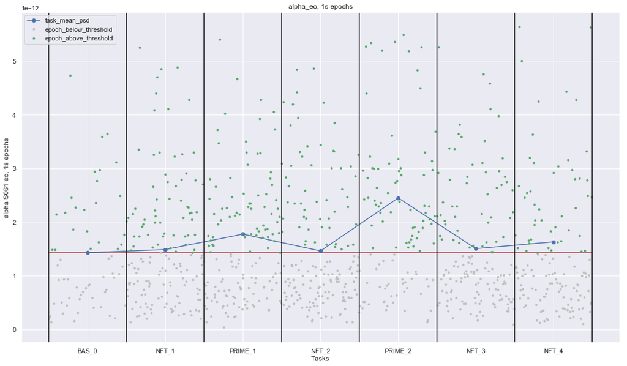

```python
#subjects to plot
subject_l=["S061"] #select subjects to plot
#protocol to plot
protocol="eo"
#sheets to plot
sheet_l=['alpha'] #['alpha']-one band or ['theta','alpha','SMR','beta']-multiple band
sheet_df_d={} #sheet df dict
for sheet in sheet_l:
    sheet_df_d[sheet] = pd.read_excel(database_path, sheet_name=sheet)
#feature to plot
feat_l=['epoch_a'] #for now only epoch_a implemented
index_epoch_a=0 #index of the value to use of the list of list; e.g. alpha=>index=0
#tasks to plot
task_l=[] #[("x axis name",["tasks to use"])]
if protocol=="eo":
    #task_l=[("BAS_0",['rest_eo_2']), ("NFT_1",['alpha_eo_3']), ("NFT_2",['alpha_eo_5','alpha_eo_7']), ("NFT_3",['alpha_eo_9','alpha_eo_11']), ("NFT_4",['alpha_eo_14'])]
    task_l=[("BAS_0",['rest_eo_2']), ("NFT_1",['alpha_eo_3']), ("PRIME_1", ["rest_eo_4", "breathingv6_eo_4","imageryv6_eo_4", "rest_eo_6", "breathingv6_eo_6","imageryv6_eo_6"]), ("NFT_2",['alpha_eo_5','alpha_eo_7']), ("PRIME_2", ["rest_eo_8", "breathingv6_eo_8","imageryv6_eo_8", "rest_eo_10", "breathingv6_eo_10","imageryv6_eo_10"]),("NFT_3",['alpha_eo_9','alpha_eo_11']), ("NFT_4",['alpha_eo_14'])]
if protocol=="ec":
    #task_l=[("BAS_0",['rest_ec_1']), ("NFT_1",['alpha_ec_5','alpha_ec_7']), ("NFT_2",['alpha_eo_9','alpha_eo_11'])]
    task_l=[("BAS_0",['rest_ec_1']), ("PRIME_1", ["rest_ec_4", "breathingv6_ec_4","imageryv6_ec_4", "rest_ec_6", "breathingv6_ec_6","imageryv6_ec_6"]), ("NFT_1",['alpha_ec_5','alpha_ec_7']),  ("PRIME_2", ["rest_ec_8", "breathingv6_ec_8","imageryv6_ec_8", "rest_ec_10", "breathingv6_ec_10","imageryv6_ec_10"]), ("NFT_2",['alpha_ec_9','alpha_ec_11'])]
#SAVE - file_sufix to add to filename and plot
file_sufix=protocol+", 1s epochs" #title and file sufix of plots
save=False
#PLOT BANDS
plot_stats=False
task_ref_stats=task_l[0][0]#reference task to make stats
scale=1

#PLOT SUBJECTs
e2_f.plot_subject(datadir, save=save,subject_l=subject_l,task_l=task_l, sheet_l=sheet_l, sheet_df_d=sheet_df_d, feat_l=feat_l, file_sufix=file_sufix, uplims=True, lolims=True, plot_stats=plot_stats, task_ref_stats=task_ref_stats, scale=scale, index_epoch_a=index_epoch_a)
```

```python
#alpha groups responders
df=eeg_alpha_groups
EG_eo=df['subject'].loc[(df['group']=='EG') & (df['eo_EX_SUB']!=1)]
CG_eo=df['subject'].loc[(df['group']=='CG') & (df['eo_EX_SUB']!=1)]
EG_ec=df['subject'].loc[(df['group']=='EG') & (df['ec_EX_SUB']!=1)]
CG_ec=df['subject'].loc[(df['group']=='CG') & (df['ec_EX_SUB']!=1)]
EG_eo_NFT_pos=df['subject'].loc[(df['eo_NFT_+']==1) & (df['group']=='EG')]
CG_eo_NFT_pos=df['subject'].loc[(df['eo_NFT_+']==1) & (df['group']=='CG')]
EG_ec_NFT_pos=df['subject'].loc[(df['ec_NFT_+']==1) & (df['group']=='EG')]
CG_ec_NFT_pos=df['subject'].loc[(df['ec_NFT_+']==1) & (df['group']=='CG')]
print("EG_eo_NFT_+ : {}/{}={:.2f}%".format( len(EG_eo_NFT_pos), len(EG_eo), 100*len(EG_eo_NFT_pos)/float(len(EG_eo))))
print("CG_eo_NFT_+ : {}/{}={:.2f}%".format( len(CG_eo_NFT_pos), len(CG_eo), 100*len(CG_eo_NFT_pos)/float(len(CG_eo))))
print("EG_ec_NFT_+ : {}/{}={:.2f}%".format( len(EG_ec_NFT_pos), len(EG_ec), 100*len(EG_ec_NFT_pos)/float(len(EG_ec))))
print("CG_ec_NFT_+ : {}/{}={:.2f}%".format( len(CG_ec_NFT_pos), len(CG_ec), 100*len(CG_ec_NFT_pos)/float(len(CG_ec))))
```

```
EG_eo_NFT_+ : 17/30=56.67%
CG_eo_NFT_+ : 15/31=48.39%
EG_ec_NFT_+ : 1/30=3.33%
CG_ec_NFT_+ : 3/31=9.68%
```

### D: Did we change the number of responders, in just a single session?

- D: In thet EG, even with a single session approach we were able to get closer to the literature inifficacy arround 40% of the population.
  - EG_eo*NFT*+ : 17/30=57%
  - CG_eo*NFT*+ : 15/31=48%

# Between Subjects

```python
def plot_between_subjects(group_l=['CG', 'EG'], sheet_l=['alpha'],
                          feat_l=['ratio_power_threshold'],
                          protocol='eo', select_subjects=False, exclude_subjects=True,
                          save=False, plot_stats=True, stats_test='ttest_pair',
                          scale=10, stats_loc=0.3, group_sufix='allsubjects'):
    #group to plot
    group_l=group_l # ["CG", "EG"], ["CG"], ["EG"]
    #protocol to plot
    protocol=protocol
    #sheets to plot
    sheet_l=sheet_l #['alpha']-one band or ['theta','alpha','SMR','beta']-multiple band
    sheet_df_d={} #sheet df dict
    for sheet in sheet_l:
        sheet_df_d[sheet] = pd.read_excel(database_path, sheet_name=sheet)
        #select subjects - using 'eeg_alpha_groups'
        sheet_df=sheet_df_d[sheet]
        select_subjects=select_subjects
        group_sufix=group_sufix#default
        if select_subjects and not group_sufix=='allsubjects':
            group_sufix=group_sufix
            group=protocol+'_'+group_sufix #group of subjects
            subjects_l=eeg_alpha_groups['subject'].loc[(eeg_alpha_groups[group]==1)].tolist() #select subjects to list
            sheet_df=sheet_df.loc[sheet_df['subject'].isin(subjects_l)] #get alpha features dataframe of subjects
        exclude_subjects=exclude_subjects
        if exclude_subjects:
            group=protocol+'_EX_SUB' #group of subjects
            subjects_l=eeg_alpha_groups['subject'].loc[(eeg_alpha_groups[group]==1)].tolist() #select subjects to list
            sheet_df=sheet_df.loc[sheet_df['subject'].isin(subjects_l) != True]    #print([alpha_df['subject'].isin(subjects_l) != True])
        sheet_df_d[sheet]=sheet_df #substitute sheet_df
    #feature to plot
    feat_l=feat_l #'ratio_power_threshold', 'tBAT', 'tonic_increase', 'tonic_increase_BAT'
    #tasks to plot- [("x axis name","tasks to use")]
    task_l=[]
    if protocol=="eo":
        #task_l=[("BAS_0",['rest_eo_2']), ("NFT_1",['alpha_eo_3']), ("NFT_2",['alpha_eo_5','alpha_eo_7']), ("NFT_3",['alpha_eo_9','alpha_eo_11']), ("NFT_4",['alpha_eo_14'])]
        task_l=[("BAS_0",['rest_eo_2']), ("NFT_1",['alpha_eo_3']), ("PRIME_1", ["rest_eo_4", "breathingv6_eo_4","imageryv6_eo_4", "rest_eo_6", "breathingv6_eo_6","imageryv6_eo_6"]), ("NFT_2",['alpha_eo_5','alpha_eo_7']), ("PRIME_2", ["rest_eo_8", "breathingv6_eo_8","imageryv6_eo_8", "rest_eo_10", "breathingv6_eo_10","imageryv6_eo_10"]),("NFT_3",['alpha_eo_9','alpha_eo_11']), ("NFT_4",['alpha_eo_14'])]
    if protocol=="ec":
        #task_l=[("BAS_0",['rest_ec_1']), ("NFT_1",['alpha_ec_5','alpha_ec_7']), ("NFT_2",['alpha_eo_9','alpha_eo_11'])]
        task_l=[("BAS_0",['rest_ec_1']), ("PRIME_1", ["rest_ec_4", "breathingv6_ec_4","imageryv6_ec_4", "rest_ec_6", "breathingv6_ec_6","imageryv6_ec_6"]), ("NFT_1",['alpha_ec_5','alpha_ec_7']),  ("PRIME_2", ["rest_ec_8", "breathingv6_ec_8","imageryv6_ec_8", "rest_ec_10", "breathingv6_ec_10","imageryv6_ec_10"]), ("NFT_2",['alpha_ec_9','alpha_ec_11'])]


    #SAVE - file_sufix to add to filename and plot
    file_sufix=protocol+'_'+feat_l[0]+'_'+group_sufix
    save=save

    #PLOT STATs
    plot_stats=plot_stats
    task_ref_stats=task_l[0][0]#reference task to make stats
    #1) one-sample paired ttest: 1_measurement_var=tBAT, 1_nominal_var=subjects, 2_nominal_var=task_out-task_ref ; hipotheses: ;
    # biological question: Whether the measurment var has gone up or down between task_out and task_ref.
    #null hypothesis: mean difference between paired observations is zero.
    #2) two-sample ttest (independent or dependent samples): 1_measurement_var=tBAT, 1_nominal_var=Task=['Task_out' vs 'Task_ref'];
    #assumption: normally distibuted; null hypothesis:  means of the measurement var are equal for the two categories.
    #http://www.biostathandbook.com/pairedttest.html
    stats_test=stats_test#"ttest_pair"; 'ttest_ind' , 'ttest_rel'
    scale=scale
    stats_loc=stats_loc#localization of stats
    e2_f.plot_group(datadir, save=save,group_l=group_l,task_l=task_l, sheet_l=sheet_l, sheet_df_d=sheet_df_d, feat_l=feat_l, file_sufix=file_sufix, uplims=True, lolims=True, plot_stats=plot_stats, task_ref_stats=task_ref_stats,stats_test=stats_test,stats_loc=stats_loc, scale=scale)
    return sheet_df_d, task_l
```

## eo_Allsubjects

```
INFO:e2_functions_v8:
>> PROCESSING PLOT GROUP:  CG, ratio_power_threshold
INFO:e2_functions_v8:
>> PROCESSING PLOT GROUP:  EG, ratio_power_threshold
```

```
!!!saving in: /Users/nm.costa/Google_Drive/projects/phd/research/00_DataAnalysisTools_WS/python_workspace_NC/phdproject_master/phdproject/maincode/src/functions/data_analysis/e2_pipe/jupyter_database
```

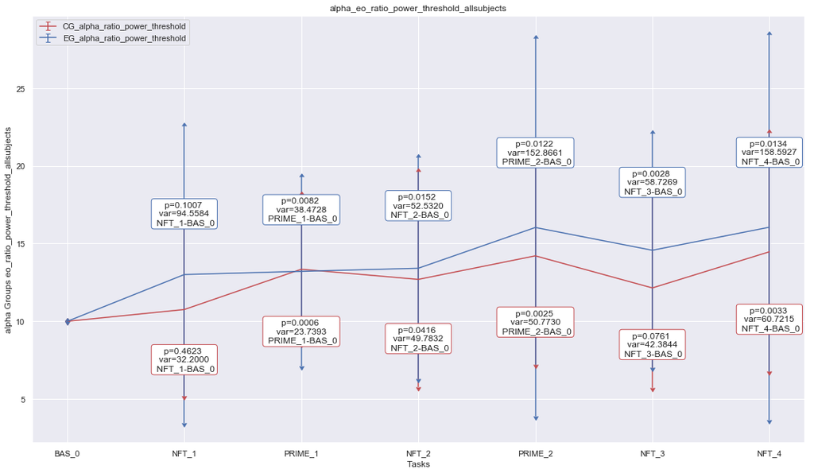

```python
sheet_df_d, task_l=plot_between_subjects(feat_l=['ratio_power_threshold'], scale=10, stats_loc=0.3, save=True)
```

```python
#DATA GROUPS TO CORRELATE
#eeg
sheet="alpha"
feat='ratio_power_threshold'
feat_df=sheet_df_d[sheet]
protocol="eo"

group="EG"
#Get tasks_l feature df
task_l_n=[[t[0], t[1]] for t in task_l] #tuple to list
for i,t in enumerate(task_l_n):
    taskid=t[1]
    df=feat_df[group+"_"+sheet+"_"+feat+"_"+taskid[0]]
    if len(taskid)>1:
        for tid in taskid[1:]:
            df=df.append(feat_df[group+"_"+sheet+"_"+feat+"_"+tid])
    task_l_n[i][1]=df
EG_task_d={t[0]: t[1] for t in task_l_n} #list to dict

group="CG"
#Get tasks_l feature df
task_l_n=[[t[0], t[1]] for t in task_l] #tuple to list
for i,t in enumerate(task_l_n):
    taskid=t[1]
    df=feat_df[group+"_"+sheet+"_"+feat+"_"+taskid[0]]
    if len(taskid)>1:
        for tid in taskid[1:]:
            df=df.append(feat_df[group+"_"+sheet+"_"+feat+"_"+tid])
    task_l_n[i][1]=df
CG_task_d={t[0]: t[1] for t in task_l_n} #list to dict
```

```python
#Chose data to compare
data_1=np.array(CG_task_d['NFT_4'])
data_1=data_1[np.logical_not(np.isnan(data_1))] #REMOVE NaN
data_2=np.array(EG_task_d['NFT_4'])
data_2=data_2[np.logical_not(np.isnan(data_2))] #REMOVE NaN
print(len(data_1))
print(len(data_2))
#T-test Independent groups
stat, p = scipy.stats.ttest_ind(data_1, data_2, axis=0, equal_var=True, nan_policy='omit')
print('ttest_statistics=%.4f, p=%.4f' % (stat, p))
```

```
31
30
ttest_statistics=-0.5914, p=0.5565
```

Feature: Ratio task asolute power/ threshold absolute power(BAS_0)

p: p-value of paired t-test

var: variance is a measure of the spread of a distribution - average degree to which each point differs from the mean.

Feature changes:

- R: overral feature increase => D: alpha power epoch distribution increases
- R: EG and CG feature increase not different => D: Single-session can't descriminate power from priming vs no-priming

Stastical feature changes:

- R: overral p-value decrease => D: alpha power epoch distribution increases significantly, therefore this training up-regulates alpha.
- R: overral variability maintains => D: If an alpha self-regulation is represented by affecting the (lowering) variability, then this single-session training design can't answer that.
- R: EG changes in variability superior to CG changes => D: Priming affects alpha power comparativily to CG.
- R: CG less variability and more constant => D: REST No-priming intervention affects less the alpha amplitude

Highlights:

- D: Does priming with external stimulation affects the self-regulation of NF?
  - D: Priming with external MM affects alpha NFT variability comparing to REST no-priming. Therefore, possibily can affect non-responders?

```
INFO:e2_functions_v8:
>> PROCESSING PLOT GROUP:  CG, tBAT
INFO:e2_functions_v8:
>> PROCESSING PLOT GROUP:  EG, tBAT
```

```
!!!saving in: /Users/nm.costa/Google_Drive/projects/phd/research/00_DataAnalysisTools_WS/python_workspace_NC/phdproject_master/phdproject/maincode/src/functions/data_analysis/e2_pipe/jupyter_database
```

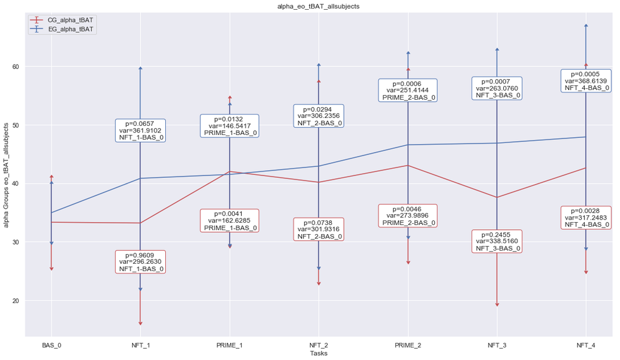

```python
sheet_df_d, task_l=plot_between_subjects(feat_l=['tBAT'],scale=100, stats_loc=0.2, save=True)
```

```python
#DATA GROUPS
#eeg
sheet="alpha"
feat="tBAT"
feat_df=sheet_df_d[sheet]
protocol="eo"

group="EG"
#Get tasks_l feature df
task_l_n=[[t[0], t[1]] for t in task_l] #tuple to list
for i,t in enumerate(task_l_n):
    taskid=t[1]
    df=feat_df[group+"_"+sheet+"_"+feat+"_"+taskid[0]]
    if len(taskid)>1:
        for tid in taskid[1:]:
            df=df.append(feat_df[group+"_"+sheet+"_"+feat+"_"+tid])
    task_l_n[i][1]=df
EG_task_d={t[0]: t[1] for t in task_l_n} #list to dict

group="CG"
#Get tasks_l feature df
task_l_n=[[t[0], t[1]] for t in task_l] #tuple to list
for i,t in enumerate(task_l_n):
    taskid=t[1]
    df=feat_df[group+"_"+sheet+"_"+feat+"_"+taskid[0]]
    if len(taskid)>1:
        for tid in taskid[1:]:
            df=df.append(feat_df[group+"_"+sheet+"_"+feat+"_"+tid])
    task_l_n[i][1]=df
CG_task_d={t[0]: t[1] for t in task_l_n} #list to dict
```

```python
#Chose data to compare
data_1=np.array(CG_task_d['NFT_4'])
data_1=data_1[np.logical_not(np.isnan(data_1))] #REMOVE NaN
data_2=np.array(EG_task_d['NFT_4'])
data_2=data_2[np.logical_not(np.isnan(data_2))] #REMOVE NaN
print(len(data_1))
print(len(data_2))
#T-test Independent groups
stat, p = scipy.stats.ttest_ind(data_1, data_2, axis=0, equal_var=True, nan_policy='omit')
print('ttest_statistics=%.4f, p=%.4f' % (stat, p))
```

```
31
30
ttest_statistics=-1.1142, p=0.2697
```

Feature: tBAT (number of epochs above threshold / total number of epochs)

Feature changes:

- R: overral feature increase => D: More epochs above threshold
- R: EG and CG feature increase not different => D: Single-session can't descriminate power from priming vs no-priming

Stastical feature changes:

- R: overral p-value decrease => D: number of epochs above threshold increase significantly
- R: overral variability maintains => D: Ideally(see NFT_+) if all subjects increase the number of epochs above the threshold the distribution variance should decrease, however it seems that a similar distribution is maintained in a single-session design. Therefore, the number of responders and non-reponders should be the same between blocks.
- R: EG p-value has a more sinificant decrease <0.001 => D: Alpha epochs above the threshold are affected wih more significance, comparing with the no-priming intervention.
- R: EG p-value are constantly decreasing, while CG p-value is changing abruptly => D: The alpha epochs above threshold are constantly increasing in the EG population, therefore the priming seems to assist the alpha regulation, maintaining a similar alpha distribution.

Highlights:

- R: Are MM stimuli a good self-regulation primer, compared with the standard rest baseline tasks used in Neurofeedback? Does priming with external stimulation assists participants in self-regulate their Neurofeedback?
  - MM stimuli seems to assist alpha regulation increasing constantly the number of epochs above threshold, comparing with the REST no-priming that seems to randomly assist the epochs above threshold.

```
INFO:e2_functions_v8:
>> PROCESSING PLOT GROUP:  CG, tonic_increase
INFO:e2_functions_v8:
>> PROCESSING PLOT GROUP:  EG, tonic_increase
```

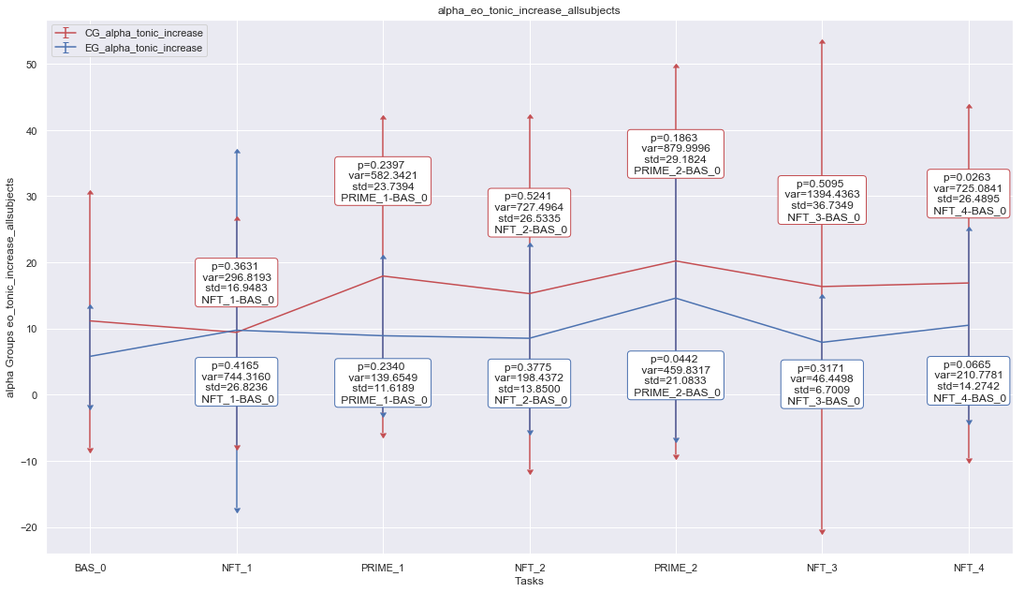

```python
plot_between_subjects(feat_l=['tonic_increase'],scale=1e13, stats_loc=-0.8)
```

Feature: tonic increase (absolute power * tBAT)

Feature changes:

Stastical feature changes:

Highlights:

- Instead of absolute power use ratio_power_threshold? Because absolute power is strange

```
INFO:e2_functions_v8:
>> PROCESSING PLOT GROUP:  CG, tonic_increase_BAT
INFO:e2_functions_v8:
>> PROCESSING PLOT GROUP:  EG, tonic_increase_BAT
```

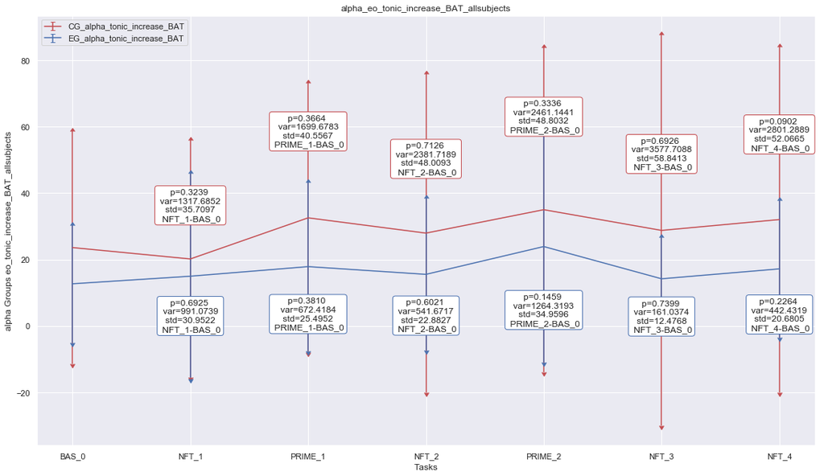

```python
plot_between_subjects(feat_l=['tonic_increase_BAT'],scale=1e13, stats_loc=-0.8)
```

## eo*NFT*+

```
INFO:e2_functions_v8:
>> PROCESSING PLOT GROUP:  CG, ratio_power_threshold
INFO:e2_functions_v8:
>> PROCESSING PLOT GROUP:  EG, ratio_power_threshold
```

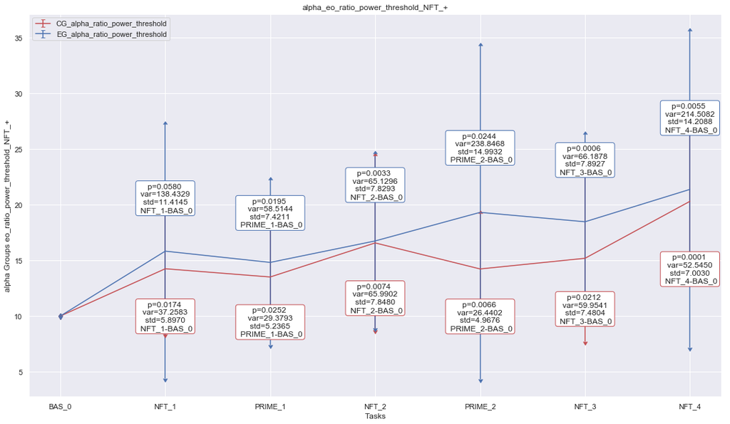

```python
plot_between_subjects(feat_l=['ratio_power_threshold'], scale=10,
                      stats_loc=0.3, select_subjects=True,
                      group_sufix='NFT_+')
```

Highlights:

- D: Does priming with external stimulation affects the self-regulation of NF?
  - D: Priming with external MM affects responders alpha NFT variability comparing to REST no-priming.
  - D: Having more variability means more stimulation of alpha.

```
INFO:e2_functions_v8:
>> PROCESSING PLOT GROUP:  CG, tBAT
INFO:e2_functions_v8:
>> PROCESSING PLOT GROUP:  EG, tBAT
```

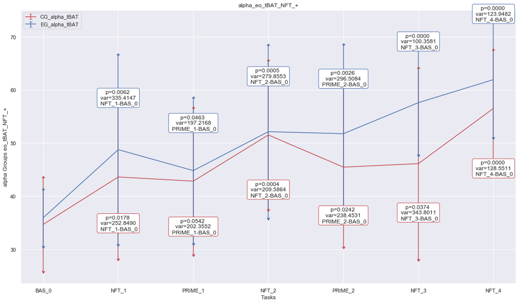

```python
plot_between_subjects(feat_l=['tBAT'], scale=100,
                      stats_loc=0.2, select_subjects=True,
                      group_sufix='NFT_+')
```

Feature: tBAT (number of epochs above threshold / total number of epochs)

Stastical feature changes:

- R: Overral variability decreased => D: Ideally if all subjects increase the number of epochs above the threshold the distribution variance should decrease. The responders follow this tendency.

Highlights:

- D: This single-session training design significantly increases the epochs above threshold

```
INFO:e2_functions_v8:
>> PROCESSING PLOT GROUP:  CG, tonic_increase
INFO:e2_functions_v8:
>> PROCESSING PLOT GROUP:  EG, tonic_increase
```

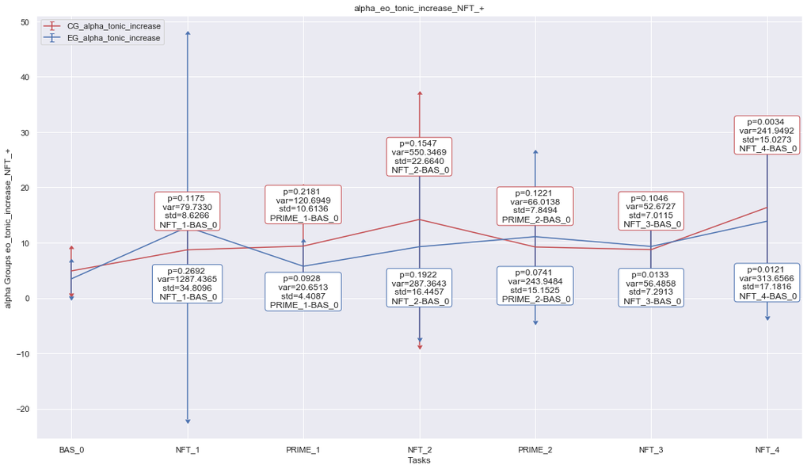

```python
plot_between_subjects(feat_l=['tonic_increase'],scale=1e13, stats_loc=-0.8, select_subjects=True,
                      group_sufix='NFT_+')
```

Highlights:

- D: The absolute power in responders and the number of epochs above threshold is very similar

```
INFO:e2_functions_v8:
>> PROCESSING PLOT GROUP:  CG, tonic_increase_BAT
INFO:e2_functions_v8:
>> PROCESSING PLOT GROUP:  EG, tonic_increase_BAT
```

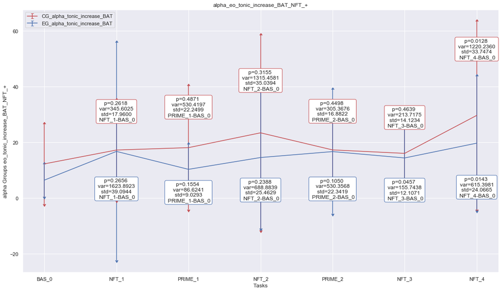

```python
plot_between_subjects(feat_l=['tonic_increase_BAT'],scale=1e13, stats_loc=-0.8, select_subjects=True,
                      group_sufix='NFT_+')
```

Highlights:

- D: In responders, The absolute power above threshold and the number of epochs above threshold has more variance in CG, therefore the tonic increase is less stable.

## ec_Allsubjects

```
INFO:e2_functions_v8:
>> PROCESSING PLOT GROUP:  CG, ratio_power_threshold
INFO:e2_functions_v8:
>> PROCESSING PLOT GROUP:  EG, ratio_power_threshold
```

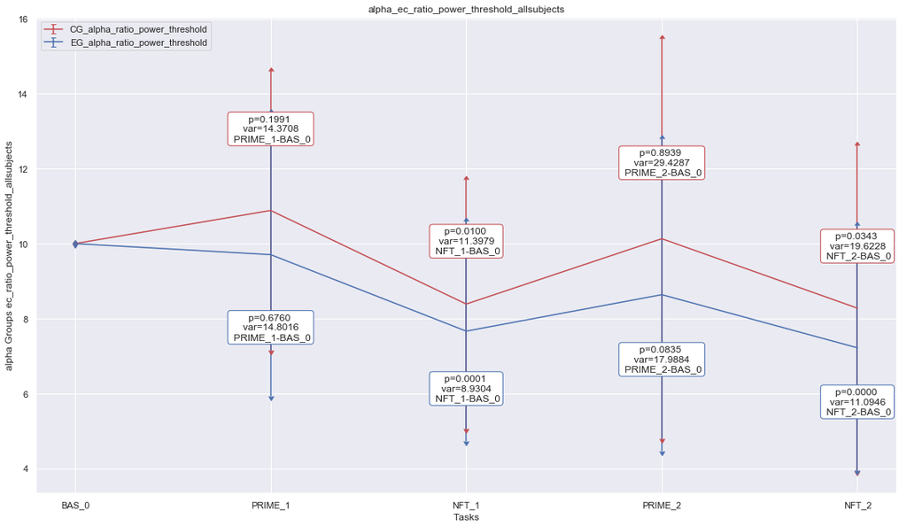

```python
plot_between_subjects(feat_l=['ratio_power_threshold'],protocol='ec',plot_stats=True,
                      stats_test='ttest_ind', scale=10, stats_loc=-0.2)
```

```
INFO:e2_functions_v8:
>> PROCESSING PLOT GROUP:  CG, tBAT
INFO:e2_functions_v8:
>> PROCESSING PLOT GROUP:  EG, tBAT
```

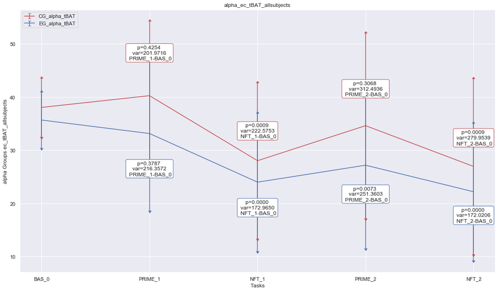

```python
plot_between_subjects(feat_l=['tBAT'],protocol='ec',plot_stats=True,
                      stats_test='ttest_ind', scale=100, stats_loc=-0.2)
```

```
INFO:e2_functions_v8:
>> PROCESSING PLOT GROUP:  CG, tonic_increase
INFO:e2_functions_v8:
>> PROCESSING PLOT GROUP:  EG, tonic_increase
```

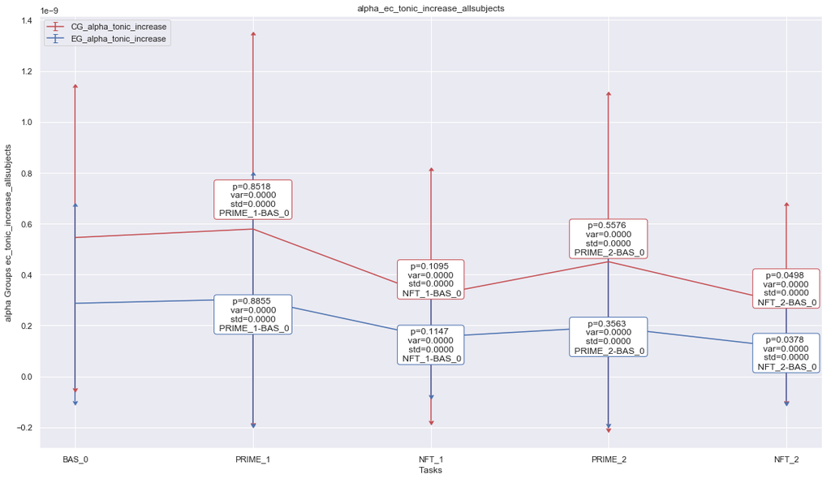

```python
plot_between_subjects(feat_l=['tonic_increase'],protocol='ec',plot_stats=True,
                      stats_test='ttest_ind', scale=100, stats_loc=-0.2)
```

```
INFO:e2_functions_v8:
>> PROCESSING PLOT GROUP:  CG, tonic_increase_BAT
INFO:e2_functions_v8:
>> PROCESSING PLOT GROUP:  EG, tonic_increase_BAT
```

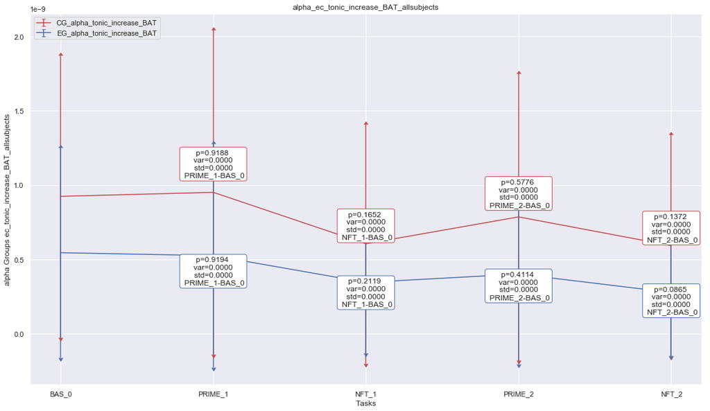

```python
plot_between_subjects(feat_l=['tonic_increase_BAT'],protocol='ec',plot_stats=True,
                      stats_test='ttest_ind', scale=100, stats_loc=-0.2)
```

## ec*NFT*-

```
INFO:e2_functions_v8:
>> PROCESSING PLOT GROUP:  CG, ratio_power_threshold
INFO:e2_functions_v8:
>> PROCESSING PLOT GROUP:  EG, ratio_power_threshold
```

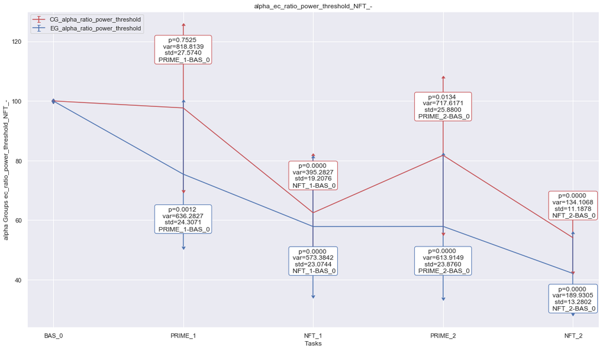

```python
plot_between_subjects(feat_l=['ratio_power_threshold'],
                      protocol='ec',plot_stats=True,
                      stats_test='ttest_ind',
                      scale=100,stats_loc=-0.2, select_subjects=True,
                      group_sufix='NFT_-')
```

```
INFO:e2_functions_v8:
>> PROCESSING PLOT GROUP:  CG, tBAT
INFO:e2_functions_v8:
>> PROCESSING PLOT GROUP:  EG, tBAT
```

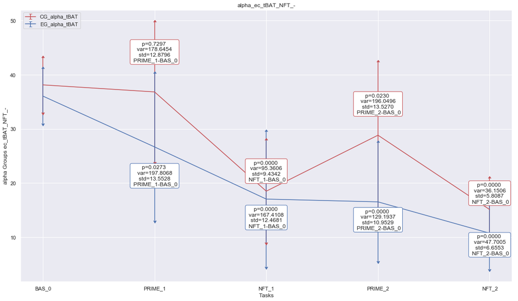

```python
plot_between_subjects(feat_l=['tBAT'],
                      protocol='ec',plot_stats=True,
                      stats_test='ttest_ind',
                      scale=100,stats_loc=-0.2, select_subjects=True,
                      group_sufix='NFT_-')
```